# Random forest

## Rappel

Le principe du random forest est de trouver à quelle classe appartient une donnée grâce à un vote à la majorité dans un sous-ensemble d'arbres créés.

## Présentation du problème

Nous allons construire un modèle sur le jeu de données des fleurs d'iris, qui est un jeu de classification très célèbre. Il comprend la longueur des sépales, la largeur des sépales, la longueur des pétales, la largeur des pétales et le type de fleurs. Il y a trois espèces ou classes : *setosa*, *versicolor* et *virginica*.

Nous allons construire un modèle pour classer le type de fleur.

## Imporation du dataset

```python
from sklearn import datasets
iris = datasets.load_iris()
```

```python
#Transformation de l'array en datagrame
import pandas as pd
data = pd.DataFrame({
    'sepal length':iris.data[:,0],
    'sepal width':iris.data[:,1],
    'petal length':iris.data[:,2],
    'petal width':iris.data[:,3],
    'species':iris.target,
})
data.head()
```

|  | sepal length | sepal width | petal length | petal width | species |
| --- | --- | --- | --- | --- | --- |
| 0 | 5.1 | 3.5 | 1.4 | 0.2 | 0 |
| 1 | 4.9 | 3.0 | 1.4 | 0.2 | 0 |
| 2 | 4.7 | 3.2 | 1.3 | 0.2 | 0 |
| 3 | 4.6 | 3.1 | 1.5 | 0.2 | 0 |
| 4 | 5.0 | 3.6 | 1.4 | 0.2 | 0 |

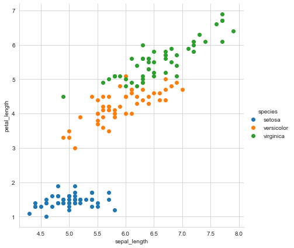

```python
import seaborn as sns
import matplotlib.pyplot as plt

iris = sns.load_dataset('iris')

sns.set_style("whitegrid")

sns.FacetGrid(iris, hue ="species",
              height = 6).map(plt.scatter,
                              'sepal_length',
                              'petal_length').add_legend()
```

Avant d'aller plus loin, il est nécessaire d'indiquer les espèces!

- 0 correspond à l'espèce *setosa*
- 1 correspond à l'espèce *versicolor*
- 2 correspond à l'espèce *virginica*

## Entrainement de l'algorithme

### Split du dataset

```python
from sklearn.model_selection import train_test_split

X = data[['sepal length', 'sepal width', 'petal length', 'petal width']]
y = data['species']

# Split le dataset en training et test set
X_train, X_test, y_train, y_test = train_test_split(X, y, test_size=0.3)
```

### Random forest

```python
from sklearn.ensemble import RandomForestClassifier

# Création d'un classifieur
clf = RandomForestClassifier(n_estimators=100)

# Entrainement du modèle
clf.fit(X_train, y_train)

y_pred = clf.predict(X_test)
```

### Vérification de la précision du modèle

```python
from sklearn import metrics
print("Accuracy : ", metrics.accuracy_score(y_test, y_pred))
```

```
Accuracy :  0.9333333333333333
```

## Prédiction pour une plante

Prenons trois exemples :

- plante 1 : 3cm longueur sépales, 5cm largeur sépales, 4cm longueur pétales et 2cm largeur pétales
- plante 2 : 10cm longueur sépales, 5cm largeur sépales, 14cm longueur pétales et 3cm largeur pétales
- plante 3 : 1cm longueur sépales, 2cm largeur sépales, 1cm longueur pétales et 2cm largeur pétales

```python
clf.predict([[3,5,4,2]])
```

```
array([2])
```

```python
clf.predict([[10,5,14,3]])
```

```
array([2])
```

```python
clf.predict([[1,2,1,2]])
```

```
array([0])
```